# Calor y complicaciones en el embarazo

Rebeca Ojer Aransáez, Nicolás Planas García y Milagros Varela San

2026-11-23

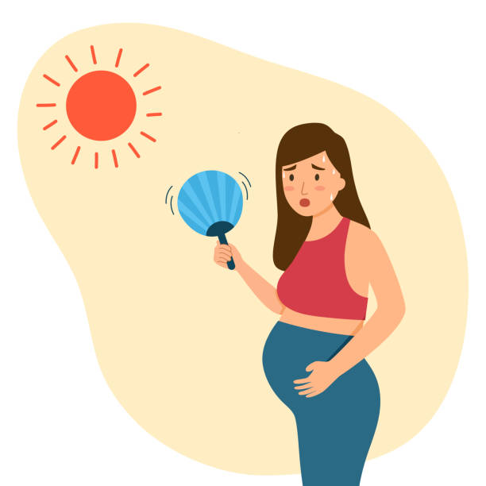

## Enlace del Repositorio

https://github.com/nicolassplanass/Seminario-FFDD-Grupo-G

## Introducción

El aumento constante de las temperaturas globales se ha convertido en una de las amenazas más relevantes para la salud pública. Si bien los efectos del calor extremo suelen analizarse frecuentemente en poblaciones vulnerables como los adultos mayores o personas con patologías crónicas, el impacto sobre la salud materno-infantil representa un área crítica y, a menudo, menos visibilizada. El organismo materno experimenta adaptaciones fisiológicas complejas para mantener la termorregulación; sin embargo, cuando las temperaturas ambientales superan los umbrales de tolerancia (como evidencian los registros térmicos recientes), se desencadenan respuestas de estrés térmico que pueden comprometer gravemente la homeostasis del embarazo.

En este seminario queremos analizar la relación directa entre la exposición al calor extremo y una serie de desenlaces clínicos graves en la salud materno-infantil a nivel provincial. A través del cruce de indicadores climáticos con registros de salud, el trabajo examina la incidencia de partos prematuros, mortalidad fetal tardía y mortalidad perinatal. El propósito es fundamentar con datos la necesidad de implementar estrategias de prevención sociosanitaria adaptadas a las etapas gestacional y perinatal ante el escenario climático actual.

## Objetivos

El objetivo general es **evaluar la asociación entre la exposición a temperaturas extremas y la incidencia de complicaciones obstétricas y mortalidad perinatal a nivel provincial**, mediante el cruce de registros climáticos históricos y recientes con indicadores de salud materno-infantil. Para ello, debemos:

- **Caracterizar la exposición térmica provincial:** analizar las temperaturas máxima, media y mínima de 2024 y calcular sus anomalías respecto a la serie de referencia 1991-2020.
- **Evaluar el impacto en el parto y la prematuridad:** analizar la relación entre la temperatura y la tasa de partos prematuros.
- **Cuantificar el efecto sobre la mortalidad fetal y perinatal:** estudiar la correlación entre la temperatura y la mortalidad fetal tardía y la mortalidad perinatal.

## Metodología: Importación y Preparación de los datos

Los datos sanitarios (mortalidad perinatal, mortalidad fetal tardía, partos prematuros y nacimientos por provincia) proceden del Instituto Nacional de Estadística (INE) en formato JSON y CSV. Los datos climáticos son ficheros CSV con las temperaturas máximas, medias y mínimas de 2024 por provincia y la temperatura media del periodo de referencia 1991-2020. Todos se encuentran en la carpeta `INPUT` del proyecto.

Para trabajar con ellos utilizamos las siguientes librerías:

```r
library(ggplot2)
library(tidyverse)
library(tidyr)
library(dplyr)
library(patchwork)
library(mapSpain)
library(knitr)
library(jsonlite)
library(kableExtra)
library(DT)
```

### Importación de los datos sanitarios

La carga de los datos directamente desde los ficheros JSON es lenta, porque R tiene que leer e interpretar todo el texto, reconocer su estructura y convertirlo en un data frame cada vez que se ejecuta el documento. Para evitarlo, lo que vamos a realizar es que una vez que leamos el JSON, lo guardamos en formato RDS, que es el formato binario nativo de R. Este formato guarda el objeto ya procesado y comprimido, así que en las ejecuciones siguientes se carga casi al instante con `readRDS()`. Además, el código compara las fechas de modificación de los dos ficheros. Si el JSON es más reciente que el RDS, por ejemplo porque se han descargado datos nuevos, el RDS se vuelve a generar automáticamente. Así ganamos velocidad sin arriesgarnos a trabajar con datos desactualizados. Aplicamos esta misma estrategia a los tres conjuntos de datos: mortalidad perinatal, muerte fetal tardía y partos prematuros.

```r
# Carga inicial de la importación de datos (antes de la mejora de tiempo con el RDS)
# MORTALIDAD PERINATAL
Mortalidad_Perinatal <- fromJSON(
  "../INPUT/Mortalidad_Perinatal.json",
  simplifyVector = FALSE
)

# MORTALIDAD FETAL TARDÍA
Mortalidad_Fetal_Tardia <- fromJSON(
  "../INPUT/Mortalidad_Fetal_Tardia.json",
  simplifyVector = FALSE
)
# PARTOS PREMATUROS POR PROVINCIA
Partos_Prematuros_Provincias <- fromJSON(
  "../INPUT/Partos_Prematuros_Provincias.json",
  simplifyVector = FALSE
)
```

Mortalidad Perinatal

```r
# Comprobar si existe el RDS o si ha cambiado el JSON
if (!file.exists("../INPUT/Mortalidad_Perinatal.rds") ||
    file.info("../INPUT/Mortalidad_Perinatal.json")$mtime >
    file.info("../INPUT/Mortalidad_Perinatal.rds")$mtime) {

  # JSON original
  Mortalidad_Perinatal <- fromJSON(
    "../INPUT/Mortalidad_Perinatal.json",
    simplifyVector = FALSE
  )

  # JSON en una tabla
  Mortalidad_Perinatal_tabla <- map_dfr(
    Mortalidad_Perinatal,
    function(serie) {

      datos <- map_dfr(
        serie$Data,
        function(fila) {
          tibble(
            Fecha = fila$Fecha,
            T3_TipoDato = fila$T3_TipoDato,
            T3_Periodo = fila$T3_Periodo,
            Anyo = fila$Anyo,
            Valor = fila$Valor
          )
        }
      )

      datos$COD <- serie$COD
      datos$Nombre <- serie$Nombre
      datos$T3_Unidad <- serie$T3_Unidad

      datos
    }
  )

  # Filtrar mortalidad perinatal del año 2024
  Mortalidad_Perinatal_2024 <- Mortalidad_Perinatal_tabla %>%
    filter(Anyo == 2024)

  # Seleccionar el total de 2024
  Mortalidad_Perinatal_2024_Total <- Mortalidad_Perinatal_tabla %>%
    filter(Anyo == 2024) %>%
    slice(seq(1, n(), by = 3))

  # Guardar los resultados en formato RDS
  saveRDS(
    list(
      tabla = Mortalidad_Perinatal_tabla,
      datos_2024 = Mortalidad_Perinatal_2024,
      total_2024 = Mortalidad_Perinatal_2024_Total
    ),
    "../INPUT/Mortalidad_Perinatal.rds"
  )

} else {

  # Cargar los datos directamente desde el RDS
  datos_guardados <- readRDS("../INPUT/Mortalidad_Perinatal.rds")

  Mortalidad_Perinatal_tabla <- datos_guardados$tabla
  Mortalidad_Perinatal_2024 <- datos_guardados$datos_2024
  Mortalidad_Perinatal_2024_Total <- datos_guardados$total_2024

}
```

```r
# Comprobar si existe el RDS o si ha cambiado el JSON
if (!file.exists("../INPUT/Mortalidad_Fetal_Tardia.rds") ||
    file.info("../INPUT/Mortalidad_Fetal_Tardia.json")$mtime >
    file.info("../INPUT/Mortalidad_Fetal_Tardia.rds")$mtime) {

  # Cargar mortalidad fetal tardía
  Mortalidad_Fetal_Tardia <- fromJSON(
    "../INPUT/Mortalidad_Fetal_Tardia.json",
    simplifyVector = FALSE
  )

  # CONVERSIÓN A TABLA
  # MORTALIDAD FETAL TARDÍA

  Mortalidad_Fetal_Tardia_tabla <- map_dfr(
    Mortalidad_Fetal_Tardia,
    function(serie) {

      datos <- map_dfr(
        serie$Data,
        function(fila) {
          tibble(
            Fecha = fila$Fecha,
            T3_TipoDato = fila$T3_TipoDato,
            T3_Periodo = fila$T3_Periodo,
            Anyo = fila$Anyo,
            Valor = fila$Valor
          )
        }
      )

      datos$COD <- serie$COD
      datos$Nombre <- serie$Nombre
      datos$T3_Unidad <- serie$T3_Unidad

      datos
    }
  )

  # Filtrar AÑO 2024
  Mortalidad_Fetal_Tardia_2024 <- Mortalidad_Fetal_Tardia_tabla %>%
    filter(Anyo == 2024)

  # Filtrar POSICIONES 1, 4, 7...
  Mortalidad_Fetal_Tardia_2024_total <- Mortalidad_Fetal_Tardia_2024 %>%
    slice(seq(1, n(), by = 3))

  # Guardar los resultados en formato RDS
  saveRDS(
    list(
      tabla = Mortalidad_Fetal_Tardia_tabla,
      datos_2024 = Mortalidad_Fetal_Tardia_2024,
      total_2024 = Mortalidad_Fetal_Tardia_2024_total
    ),
    "../INPUT/Mortalidad_Fetal_Tardia.rds"
  )

} else {

  # Cargar los datos directamente desde el RDS
  datos_guardados <- readRDS("../INPUT/Mortalidad_Fetal_Tardia.rds")

  Mortalidad_Fetal_Tardia_tabla <- datos_guardados$tabla
  Mortalidad_Fetal_Tardia_2024 <- datos_guardados$datos_2024
  Mortalidad_Fetal_Tardia_2024_total <- datos_guardados$total_2024

}
```

Partos Prematuros

```r
# Cargar partos prematuros por provincias

# Comprobar si existe el RDS o si ha cambiado el JSON
if (!file.exists("../INPUT/Partos_Prematuros_Provincias.rds") ||
    file.info("../INPUT/Partos_Prematuros_Provincias.json")$mtime >
    file.info("../INPUT/Partos_Prematuros_Provincias.rds")$mtime) {


  # Cargar partos prematuros por provincias
  Partos_Prematuros_Provincias <- fromJSON(
    "../INPUT/Partos_Prematuros_Provincias.json",
    simplifyVector = FALSE
  )

  # CONVERSIÓN A TABLA
  # PARTOS PREMATUROS

  Partos_Prematuros_Provincias_tabla <- map_dfr(
    Partos_Prematuros_Provincias,
    function(serie) {

      datos <- map_dfr(
        serie$Data,
        function(fila) {
          tibble(
            Fecha = fila$Fecha,
            T3_TipoDato = fila$T3_TipoDato,
            T3_Periodo = fila$T3_Periodo,
            Anyo = fila$Anyo,
            Valor = fila$Valor
          )
        }
      )

      datos$COD <- serie$COD
      datos$Nombre <- serie$Nombre
      datos$T3_Unidad <- serie$T3_Unidad

      datos
    }
  )

  # Guardar los resultados en formato RDS
  saveRDS(
    Partos_Prematuros_Provincias_tabla,
    "../INPUT/Partos_Prematuros_Provincias.rds"
  )

} else {

  # Cargar los datos directamente desde el RDS
  Partos_Prematuros_Provincias_tabla <- readRDS(
    "../INPUT/Partos_Prematuros_Provincias.rds"
  )

}

# Mostrar la estructura y los primeros registros
# str(Partos_Prematuros_Provincias_tabla)
# head(Partos_Prematuros_Provincias_tabla)
```

### Importación de los datos meteorológicos

Temperaturas máximas de 2024

```r
TMAX_2024 <- read_delim(
  "../INPUT/TMAX_2024_Provincias.csv",
  delim = ";",
  escape_double = FALSE,
  trim_ws = TRUE,
  locale = locale(encoding = "Latin1")
)

TMAX_2024
```

```
## # A tibble: 52 × 15
##    Parámetro           región enero febrero marzo abril  mayo junio julio agosto
##    <chr>               <chr>  <dbl>   <dbl> <dbl> <dbl> <dbl> <dbl> <dbl>  <dbl>
##  1 Temperatura media … A COR…  13.6    14.9  14    18.1  17.9  20.5  23.8   24.9
##  2 Temperatura media … ALBAC…  14.1    15.3  16.3  21.2  25.6  28.6  35.5   34.8
##  3 Temperatura media … ALICA…  17.3    18.4  19.3  21.7  25.2  28.2  32.9   32.6
##  4 Temperatura media … ALMER…  16.7    17.3  18.2  21    23.9  28    32.5   32.4
##  5 Temperatura media … ARABA…  11.3    12.9  14.9  17    18.6  22.5  27.5   27.5
##  6 Temperatura media … ASTUR…  12.8    14.1  13.7  16.5  17    19.7  23.7   24.1
##  7 Temperatura media … AVILA   10.9    12.1  13    17.2  19.7  24.7  31.1   31.7
##  8 Temperatura media … BADAJ…  15.5    16.9  17.7  23    26.7  30.3  36.3   37.3
##  9 Temperatura media … ILLES…  16.8    17.4  18.7  20.6  24.2  27.9  31.7   31.9
## 10 Temperatura media … BARCE…  12.9    16.1  16.5  19.3  21.9  25.8  31     31.4
## # ℹ 42 more rows
## # ℹ 5 more variables: septiembre <dbl>, octubre <dbl>, noviembre <dbl>,
## #   diciembre <dbl>, anual <dbl>
```

Temperaturas mínimas de 2024

```r
TMIN_2024 <- read_delim(
  "../INPUT/TMIN_2024_Provincias.csv",
  delim = ";",
  escape_double = FALSE,
  trim_ws = TRUE,
  locale = locale(encoding = "Latin1")
)

TMIN_2024
```

```
## # A tibble: 52 × 15
##    Parámetro           región enero febrero marzo abril  mayo junio julio agosto
##    <chr>               <chr>  <dbl>   <dbl> <dbl> <dbl> <dbl> <dbl> <dbl>  <dbl>
##  1 Temperatura media … A COR…   6.6     7.2   6.3   8     9.1  12.7  14     15
##  2 Temperatura media … ALBAC…   3.8     3.9   5.1   6.5   9.9  14.2  18.8   19
##  3 Temperatura media … ALICA…   7.2     7.2   8.2   9.6  12.9  17.2  20.5   21.1
##  4 Temperatura media … ALMER…   7.2     7.3   8.4   9.7  12.3  16.3  20.3   20.9
##  5 Temperatura media … ARABA…   2.6     3     3.9   4.7   7    11    13.4   13.9
##  6 Temperatura media … ASTUR…   4       4.9   4.7   6.3   7.9  11.4  13.7   14.4
##  7 Temperatura media … AVILA    1.9     1.9   2.9   4.4   6    10.4  14.8   15.4
##  8 Temperatura media … BADAJ…   6       6.3   7.4   9.1  10.4  15.5  18.3   19.3
##  9 Temperatura media … ILLES…   7.4     7.7   9.1  10.2  13.2  17.5  19.9   21.1
## 10 Temperatura media … BARCE…   2.9     4.1   5.3   6.6   9.5  13.7  17.2   18
## # ℹ 42 more rows
## # ℹ 5 more variables: septiembre <dbl>, octubre <dbl>, noviembre <dbl>,
## #   diciembre <dbl>, anual <dbl>
```

Temperaturas medias de 2024

```r
TMED_2024 <- read_delim(
  "../INPUT/TMED_2024_Provincias.csv",
  delim = ";",
  escape_double = FALSE,
  trim_ws = TRUE,
  locale = locale(encoding = "Latin1")
)

TMED_2024
```

```
## # A tibble: 52 × 15
##    Parámetro         región   enero febrero marzo abril  mayo junio julio agosto
##    <chr>             <chr>    <dbl>   <dbl> <dbl> <dbl> <dbl> <dbl> <dbl>  <dbl>
##  1 Temperatura media A CORUÑA  10.1    11    10.2  13    13.5  16.6  18.9   19.9
##  2 Temperatura media ALBACETE   8.9     9.6  10.7  13.9  17.8  21.4  27.1   26.9
##  3 Temperatura media ALICANT…  12.3    12.8  13.7  15.6  19    22.7  26.7   26.8
##  4 Temperatura media ALMERIA   11.9    12.3  13.3  15.3  18.1  22.1  26.4   26.6
##  5 Temperatura media ARABA/A…   6.9     8     9.4  10.9  12.8  16.7  20.5   20.7
##  6 Temperatura media ASTURIAS   8.4     9.5   9.2  11.4  12.5  15.6  18.7   19.2
##  7 Temperatura media AVILA      6.4     7     7.9  10.8  12.9  17.5  22.9   23.5
##  8 Temperatura media BADAJOZ   10.8    11.6  12.5  16    18.5  22.9  27.3   28.3
##  9 Temperatura media ILLES B…  12.1    12.5  13.9  15.4  18.7  22.7  25.8   26.5
## 10 Temperatura media BARCELO…   7.9    10.1  10.9  12.9  15.7  19.8  24.1   24.7
## # ℹ 42 more rows
## # ℹ 5 more variables: septiembre <dbl>, octubre <dbl>, noviembre <dbl>,
## #   diciembre <dbl>, anual <dbl>
```

Temperaturas medias del periodo 1991-2020

```r
TMED_1991_2020 <- read_delim(
  "../INPUT/TMED_1991_2020_Provincias.csv",
  delim = ";",
  escape_double = FALSE,
  trim_ws = TRUE,
  locale = locale(encoding = "Latin1")
)

TMED_1991_2020
```

```
## # A tibble: 52 × 16
##    Parámetro periodo de referenci…¹ región enero febrero marzo abril  mayo junio
##    <chr>     <chr>                  <chr>  <dbl>   <dbl> <dbl> <dbl> <dbl> <dbl>
##  1 Temperat… 1991-2020              A COR…   8.3     8.6  10.4  11.6  14    16.6
##  2 Temperat… 1991-2020              ALBAC…   5.7     6.9   9.9  12.4  16.5  21.6
##  3 Temperat… 1991-2020              ALICA…   9.5    10.3  12.5  14.6  18    22.2
##  4 Temperat… 1991-2020              ALMER…   9.1     9.8  11.9  13.9  17.4  21.8
##  5 Temperat… 1991-2020              ARABA…   5       5.5   8.1   9.9  13.4  16.9
##  6 Temperat… 1991-2020              ASTUR…   6.5     6.9   8.9  10.2  12.9  15.8
##  7 Temperat… 1991-2020              AVILA    3.6     4.6   7.3   9.3  13.1  18
##  8 Temperat… 1991-2020              BADAJ…   8.2     9.5  12.5  14.6  18.5  23.3
##  9 Temperat… 1991-2020              ILLES…  10.2    10.3  12.3  14.6  18.1  22.2
## 10 Temperat… 1991-2020              BARCE…   6       7     9.8  12.1  15.9  20.1
## # ℹ 42 more rows
## # ℹ abbreviated name: ¹`periodo de referencia`
## # ℹ 7 more variables: julio <dbl>, agosto <dbl>, septiembre <dbl>,
## #   octubre <dbl>, noviembre <dbl>, diciembre <dbl>, anual <dbl>
```

### Normalización de los nombres de las provincias

Como los nombres de algunas provincias aparecen escritos de forma diferente en los archivos, creamos una función para unificarlos. Eliminamos tildes, convertimos los nombres a mayúsculas y corregimos algunas denominaciones que no coinciden.

```r
normalizar <- function(x) {
  x <- stringi::stri_trans_general(x, "Latin-ASCII")
  x <- toupper(trimws(x))

  case_when(
    x == "BALEARS, ILLES" ~ "ILLES BALEARS",
    x == "CORUNA, A"      ~ "A CORUNA",
    x == "RIOJA, LA"      ~ "LA RIOJA",
    x == "PALMAS, LAS"    ~ "LAS PALMAS",
    x == "ALAVA"          ~ "ARABA/ALAVA",
    x == "VIZCAYA"        ~ "BIZKAIA",
    x == "GUIPUZCOA"      ~ "GIPUZKOA",
    TRUE                  ~ x
  )
}
```

### Preparación de los datos climáticos

Se reúne en una única tabla, con una fila por provincia, la temperatura media, máxima y mínima de 2024, la temperatura media de referencia y la anomalía térmica (diferencia entre la temperatura media de 2024 y la de referencia).

```r
clima <- TMED_2024 %>%
  select(nombre = región, tmed_2024 = anual) %>%
  left_join(
    TMAX_2024 %>% select(región, tmax_2024 = anual),
    by = c("nombre" = "región")
  ) %>%
  left_join(
    TMIN_2024 %>% select(región, tmin_2024 = anual),
    by = c("nombre" = "región")
  ) %>%
  left_join(
    TMED_1991_2020 %>% select(región, tmed_referencia = anual),
    by = c("nombre" = "región")
  ) %>%
  mutate(
    anomalia  = tmed_2024 - tmed_referencia,
    provincia = normalizar(nombre)
  )

clima
```

```
## # A tibble: 52 × 7
##    nombre       tmed_2024 tmax_2024 tmin_2024 tmed_referencia anomalia provincia
##    <chr>            <dbl>     <dbl>     <dbl>           <dbl>    <dbl> <chr>
##  1 A CORUÑA          14.1      18.2       9.9            13.1    1     A CORUNA
##  2 ALBACETE          16        22.5       9.6            14.5    1.5   ALBACETE
##  3 ALICANTE/AL…      18.2      23.6      12.7            16.7    1.5   ALICANTE…
##  4 ALMERIA           17.7      23        12.5            16.3    1.40  ALMERIA
##  5 ARABA/ALAVA       12.7      18         7.4            11.7    1     ARABA/AL…
##  6 ASTURIAS          12.8      17.3       8.3            11.9    0.9   ASTURIAS
##  7 AVILA             12.7      18.8       6.7            11.5    1.2   AVILA
##  8 BADAJOZ           17.6      24.1      11.1            16.7    0.900 BADAJOZ
##  9 ILLES BALEA…      18.1      23.2      13.1            17.1    1     ILLES BA…
## 10 BARCELONA         15        20.7       9.2            14      1     BARCELONA
## # ℹ 42 more rows
```

### Preparación de los indicadores sanitarios

Para los tres indicadores se seleccionan los registros de 2024 y se extrae el nombre de la provincia del texto de la columna `Nombre`. Se descartan las filas de «Total Nacional» y «No residente».

```r
# Partos prematuros (recuento de partos)
prematuros <- Partos_Prematuros_Provincias_tabla %>%
  filter(Anyo == 2024) %>%
  mutate(provincia = normalizar(sub("\\..*$", "", Nombre))) %>%
  filter(!provincia %in% c("TOTAL NACIONAL", "NO RESIDENTE")) %>%
  select(provincia, partos_prematuros = Valor)

prematuros
```

```
## # A tibble: 52 × 2
##    provincia        partos_prematuros
##    <chr>                        <dbl>
##  1 ALBACETE                       175
##  2 ALICANTE/ALACANT               794
##  3 ALMERIA                        386
##  4 ARABA/ALAVA                    137
##  5 ASTURIAS                       276
##  6 AVILA                           32
##  7 BADAJOZ                        275
##  8 ILLES BALEARS                  520
##  9 BARCELONA                     2233
## 10 BIZKAIA                        351
## # ℹ 42 more rows
```

```r
# Mortalidad fetal tardía (defunciones por mil nacidos), total de ambos sexos
mortalidad_fetal <- Mortalidad_Fetal_Tardia_tabla %>%
  filter(Anyo == 2024, grepl(", Total, Todas las edades,", Nombre)) %>%
  mutate(provincia = normalizar(sub(", Mortalidad.*$", "", Nombre))) %>%
  filter(provincia != "TOTAL NACIONAL") %>%
  select(provincia, mortalidad_fetal = Valor)

# Mortalidad perinatal (defunciones por mil nacidos), total de ambos sexos
mortalidad_perinatal <- Mortalidad_Perinatal_tabla %>%
  filter(Anyo == 2024, grepl(", Total, Todas las edades,", Nombre)) %>%
  mutate(provincia = normalizar(sub(", Mortalidad.*$", "", Nombre))) %>%
  filter(provincia != "TOTAL NACIONAL") %>%
  select(provincia, mortalidad_perinatal = Valor)

mortalidad_fetal
```

```
## # A tibble: 52 × 2
##    provincia        mortalidad_fetal
##    <chr>                       <dbl>
##  1 ALBACETE                     3.52
##  2 ALICANTE/ALACANT             2.27
##  3 ALMERIA                      2.43
##  4 ARABA/ALAVA                  1.91
##  5 ASTURIAS                     4.61
##  6 AVILA                        0
##  7 BADAJOZ                      3.88
##  8 ILLES BALEARS                3.63
##  9 BARCELONA                    3.14
## 10 BIZKAIA                      4.34
## # ℹ 42 more rows
```

```r
mortalidad_perinatal
```

```
## # A tibble: 52 × 2
##    provincia        mortalidad_perinatal
##    <chr>                           <dbl>
##  1 ALBACETE                         5.87
##  2 ALICANTE/ALACANT                 3.48
##  3 ALMERIA                          5.16
##  4 ARABA/ALAVA                      4.29
##  5 ASTURIAS                         5.49
##  6 AVILA                            1.17
##  7 BADAJOZ                          6.16
##  8 ILLES BALEARS                    6.04
##  9 BARCELONA                        4.44
## 10 BIZKAIA                          4.96
## # ℹ 42 more rows
```

```r
# Importamos los nacimientos por provincia
nacimientos_ine <- read_delim(
  "../INPUT/Nacimientos_Provincias_2024.csv",
  delim = ";",
  escape_double = FALSE,
  trim_ws = TRUE,
  locale = locale(encoding = "UTF-8")
)

nacimientos_ine
```

```
## # A tibble: 52 × 2
##    provincia_ine    nacimientos_2024
##    <chr>                       <dbl>
##  1 Albacete                     2545
##  2 Alicante/Alacant            13207
##  3 Almería                      6576
##  4 Araba/Álava                  2094
##  5 Asturias                     4535
##  6 Ávila                         854
##  7 Badajoz                      4364
##  8 Balears, Illes               9067
##  9 Barcelona                   39034
## 10 Bizkaia                      6426
## # ℹ 42 more rows
```

```r
str(nacimientos_ine)
```

```
## spc_tbl_ [52 × 2] (S3: spec_tbl_df/tbl_df/tbl/data.frame)
##  $ provincia_ine   : chr [1:52] "Albacete" "Alicante/Alacant" "Almería" "Araba/Álava" ...
##  $ nacimientos_2024: num [1:52] 2545 13207 6576 2094 4535 ...
##  - attr(*, "spec")=
##   .. cols(
##   ..   provincia_ine = col_character(),
##   ..   nacimientos_2024 = col_double()
##   .. )
##  - attr(*, "problems")=<pointer: 0x000001fcd0dc55f0>
```

```r
summary(nacimientos_ine)
```

```
##    provincia_ine nacimientos_2024
##  Length   :52    Min.   :  480
##  N.unique :52    1st Qu.: 1805
##  N.blank  : 0    Median : 4170
##  Min.nchar: 4    Mean   : 6101
##  Max.nchar:22    3rd Qu.: 6248
##                  Max.   :50770
```

```r
# Nacimientos con los nombres de provincia normalizados
nacimientos <- nacimientos_ine %>%
  mutate(provincia = normalizar(provincia_ine)) %>%
  select(provincia, nacimientos_2024)

nacimientos
```

```
## # A tibble: 52 × 2
##    provincia        nacimientos_2024
##    <chr>                       <dbl>
##  1 ALBACETE                     2545
##  2 ALICANTE/ALACANT            13207
##  3 ALMERIA                      6576
##  4 ARABA/ALAVA                  2094
##  5 ASTURIAS                     4535
##  6 AVILA                         854
##  7 BADAJOZ                      4364
##  8 ILLES BALEARS                9067
##  9 BARCELONA                   39034
## 10 BIZKAIA                      6426
## # ℹ 42 more rows
```

### Comprobación de los nombres

Antes de continuar se comprueba que ninguna provincia del clima se queda sin pareja en las tablas sanitarias, y que no hay duplicados. Si la normalización es correcta, todos los resultados deben ser `character(0)` o `0`.

```r
list(
  "Clima sin partos prematuros"         = setdiff(clima$provincia, prematuros$provincia),
  "Clima sin mortalidad fetal tardía"   = setdiff(clima$provincia, mortalidad_fetal$provincia),
  "Clima sin mortalidad perinatal"      = setdiff(clima$provincia, mortalidad_perinatal$provincia),
  "Clima sin nacimientos"               = setdiff(clima$provincia, nacimientos$provincia),
  "Provincias duplicadas en el clima"   = sum(duplicated(clima$provincia)),
  "Provincias duplicadas en prematuros" = sum(duplicated(prematuros$provincia))
)
```

```
## $`Clima sin partos prematuros`
## character(0)
##
## $`Clima sin mortalidad fetal tardía`
## character(0)
##
## $`Clima sin mortalidad perinatal`
## character(0)
##
## $`Clima sin nacimientos`
## character(0)
##
## $`Provincias duplicadas en el clima`
## [1] 0
##
## $`Provincias duplicadas en prematuros`
## [1] 0
```

## Análisis descriptivo de las Temperaturas

Antes de relacionar la temperatura con las complicaciones en el embarazo, es necesario conocer cómo se comportan las variables climáticas por sí solas. En este apartado describimos las temperaturas máximas, mínimas y medias registradas durante 2024, tanto por meses como en el conjunto del año. Este análisis previo nos permite identificar los meses más cálidos, ver cuánto varía la temperatura entre unos territorios y otros, y detectar valores extremos que podrían corresponder a episodios de calor intenso. Para ello utilizamos histogramas, que muestran la forma de la distribución, y diagramas de caja, que resumen la dispersión y señalan los posibles valores atípicos.

### Distribución de las temperaturas

En primer lugar estudiamos la distribución de cada tipo de temperatura mes a mes. Para poder representar todos los meses en un mismo gráfico, reorganizamos los datos en formato largo, con una columna que indica el mes y otra con el valor de la temperatura. Después ordenamos los meses cronológicamente, con el valor anual al final, para que los gráficos se lean en orden. Empezamos por la temperatura máxima, que es la más relevante para nuestro objetivo, ya que refleja mejor la exposición al calor.

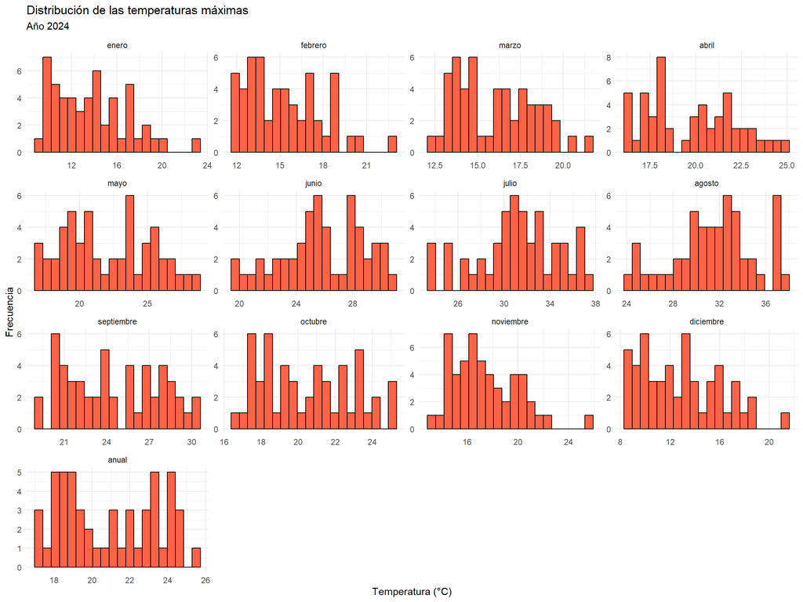

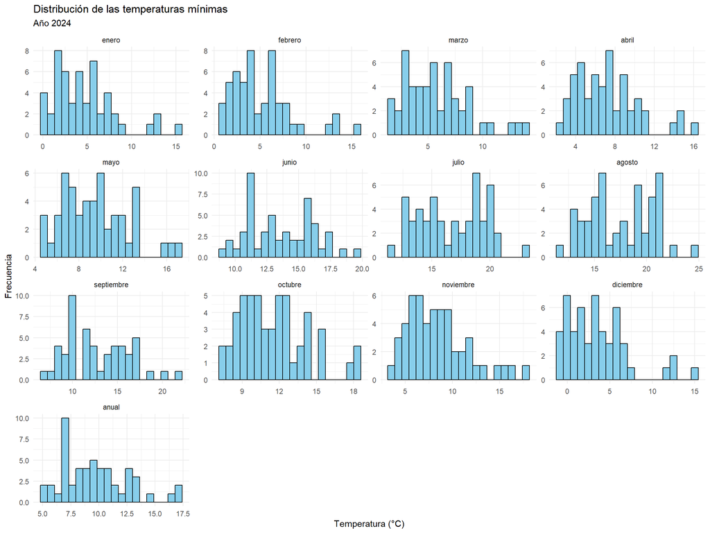

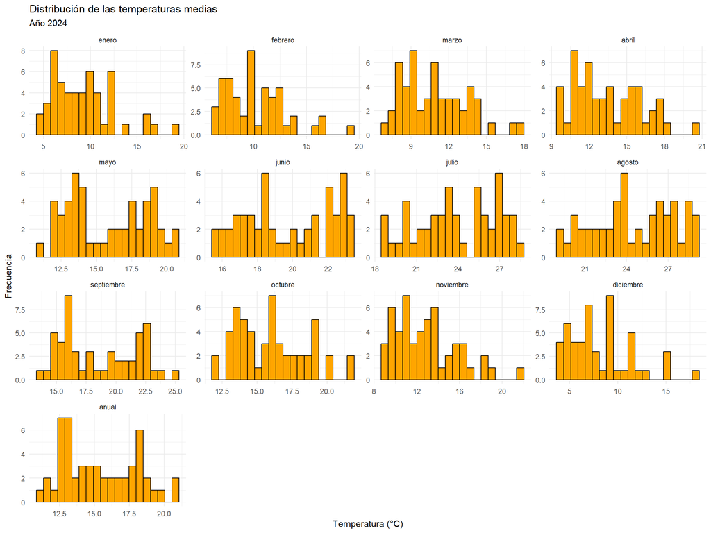

### Diagramas de Cajas

Después de estudiar la forma de las distribuciones, utilizamos diagramas de caja para comparar las temperaturas de los distintos meses. Cada caja recoge el 50 % central de los valores, la línea interior marca la mediana y los bigotes indican el rango habitual de los datos. Los puntos que quedan fuera de los bigotes son valores atípicos. Este tipo de gráfico nos permite ver de un vistazo en qué meses las temperaturas son más altas, en cuáles varían más entre territorios y si existen valores extremos. Estos valores son especialmente importantes en nuestro estudio, ya que pueden corresponder a zonas o periodos de calor intenso con un posible efecto sobre el embarazo.

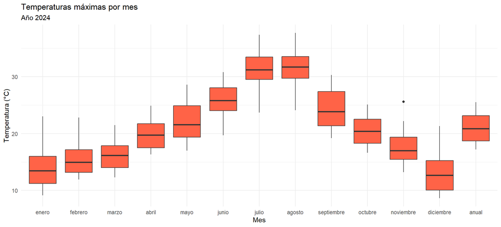

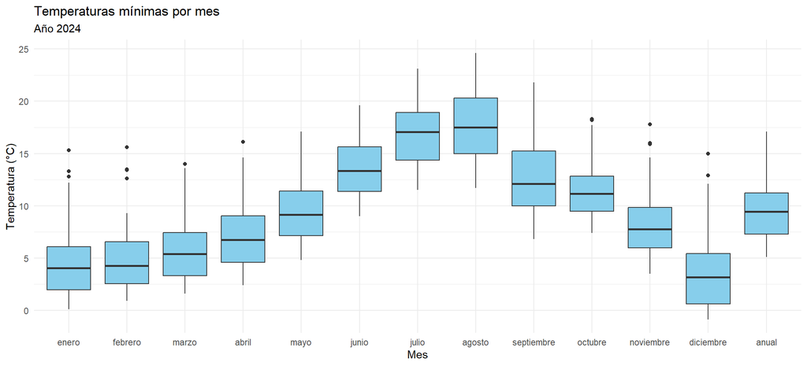

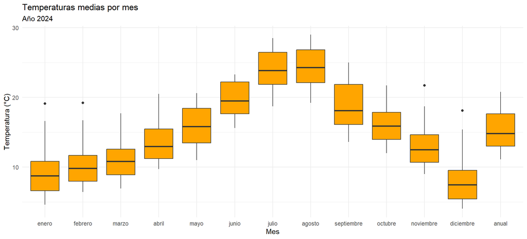

Se puede observar, que la mayoría de valores atípicos se encuentran en la distribución de las temperaturas mínimas, donde estas están por encima del valor típico, es decir, corresponden a temperaturas mínimas más altas de lo habitual. Además, aparecen sobre todo en los meses fríos (enero, febrero, marzo, abril, octubre, noviembre y diciembre). Esto indica que hay territorios donde las noches son mucho más templadas que en el resto, incluso en invierno, probablemente zonas costeras o insulares. Además, las temperaturas mínimas presentan más valores atípicos altos que las máximas y las medias. Esto es relevante para nuestro estudio, ya que unas mínimas elevadas significan noches calurosas, en las que el cuerpo no llega a recuperarse del calor del día.

### Comparación entre provincias

En este apartado comparamos las temperaturas máximas y medias registradas en las distintas provincias durante 2024. Para ello, seleccionamos las 5 provincias con los valores más altos y las 5 con los más bajos, y representamos estos resultados mediante gráficos de barras.

```r
# Provincias con temperaturas máximas más bajas y más altas
TMAX_bajas <- TMAX_2024 %>%
  arrange(anual) %>%
  slice_head(n = 5)

TMAX_altas <- TMAX_2024 %>%
  arrange(desc(anual)) %>%
  slice_head(n = 5)

# Unimos ambas tablas
TMAX_extremos <- bind_rows(TMAX_bajas, TMAX_altas)

# Comprobamos el resultado
TMAX_extremos
```

```
## # A tibble: 10 × 15
##    Parámetro           región enero febrero marzo abril  mayo junio julio agosto
##    <chr>               <chr>  <dbl>   <dbl> <dbl> <dbl> <dbl> <dbl> <dbl>  <dbl>
##  1 Temperatura media … LEON     9.1    11.9  12.3  16.5  17.3  22.9  27.9   29.2
##  2 Temperatura media … ASTUR…  12.8    14.1  13.7  16.5  17    19.7  23.7   24.1
##  3 Temperatura media … CANTA…  13      13.8  14.3  16.3  17.1  19.9  24     24.6
##  4 Temperatura media … LUGO    12.3    13.8  13.3  17.5  17.4  20.8  25.2   26.2
##  5 Temperatura media … BURGOS  10.1    12.1  13.6  16.5  18.5  23.3  29.5   29.8
##  6 Temperatura media … SEVIL…  17.7    18.8  19.7  24.6  28.6  30.5  36.6   37.1
##  7 Temperatura media … HUELVA  17.4    18.6  19.1  24    27.3  29.5  35.3   35.8
##  8 Temperatura media … CORDO…  16      17.1  18    23.5  27.7  30.8  37.4   37.7
##  9 Temperatura media … LAS P…  23      22.8  21.5  24.9  23.5  24.3  27.8   28.4
## 10 Temperatura media … CADIZ   18.3    18.9  18.9  23.2  25.8  28    33.3   33.5
## # ℹ 5 more variables: septiembre <dbl>, octubre <dbl>, noviembre <dbl>,
## #   diciembre <dbl>, anual <dbl>
```

```r
nrow(TMAX_extremos)
```

```
## [1] 10
```

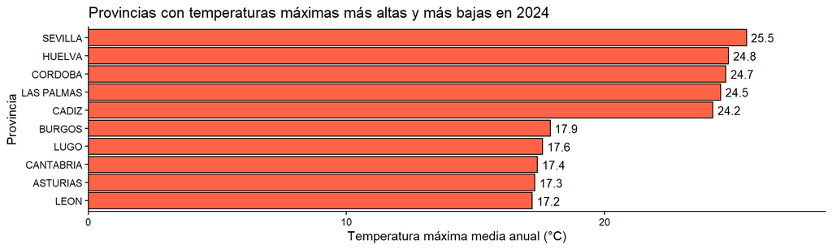

```
## # A tibble: 10 × 15
##    Parámetro           región enero febrero marzo abril  mayo junio julio agosto
##    <chr>               <chr>  <dbl>   <dbl> <dbl> <dbl> <dbl> <dbl> <dbl>  <dbl>
##  1 Temperatura media … LEON     9.1    11.9  12.3  16.5  17.3  22.9  27.9   29.2
##  2 Temperatura media … ASTUR…  12.8    14.1  13.7  16.5  17    19.7  23.7   24.1
##  3 Temperatura media … CANTA…  13      13.8  14.3  16.3  17.1  19.9  24     24.6
##  4 Temperatura media … LUGO    12.3    13.8  13.3  17.5  17.4  20.8  25.2   26.2
##  5 Temperatura media … BURGOS  10.1    12.1  13.6  16.5  18.5  23.3  29.5   29.8
##  6 Temperatura media … SEVIL…  17.7    18.8  19.7  24.6  28.6  30.5  36.6   37.1
##  7 Temperatura media … HUELVA  17.4    18.6  19.1  24    27.3  29.5  35.3   35.8
##  8 Temperatura media … CORDO…  16      17.1  18    23.5  27.7  30.8  37.4   37.7
##  9 Temperatura media … LAS P…  23      22.8  21.5  24.9  23.5  24.3  27.8   28.4
## 10 Temperatura media … CADIZ   18.3    18.9  18.9  23.2  25.8  28    33.3   33.5
## # ℹ 5 more variables: septiembre <dbl>, octubre <dbl>, noviembre <dbl>,
## #   diciembre <dbl>, anual <dbl>
```

```r
# Seleccionamos las 5 provincias con temperaturas medias más bajas
TMED_bajas <- TMED_2024 %>%
  arrange(anual) %>%
  slice_head(n = 5)

# Seleccionamos las 5 provincias con temperaturas medias más altas
TMED_altas <- TMED_2024 %>%
  arrange(desc(anual)) %>%
  slice_head(n = 5)

# Unimos las dos tablas
TMED_extremos <- bind_rows(TMED_bajas, TMED_altas)

# Comprobamos el número de provincias
nrow(TMED_extremos)
```

```
## [1] 10
```

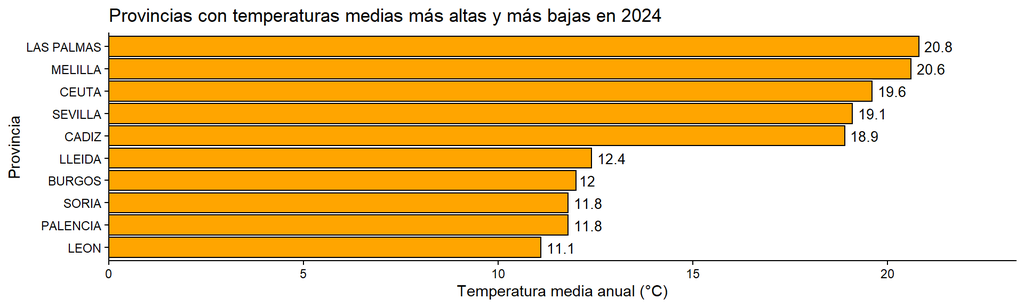

Las temperaturas medias más altas de 2024 se registraron en Las Palmas, Melilla y Ceuta, mientras que las más bajas se encontraron en León, Palencia y Soria. Se observa una diferencia considerable entre los territorios más cálidos y los fríos, especialmente entre las islas Canarias, el norte de África y algunas provincias del interior.

```
##  [1] "Parámetro"  "región"     "enero"      "febrero"    "marzo"
##  [6] "abril"      "mayo"       "junio"      "julio"      "agosto"
## [11] "septiembre" "octubre"    "noviembre"  "diciembre"  "anual"
```

```
##  [1] "Parámetro"             "periodo de referencia" "región"
##  [4] "enero"                 "febrero"               "marzo"
##  [7] "abril"                 "mayo"                  "junio"
## [10] "julio"                 "agosto"                "septiembre"
## [13] "octubre"               "noviembre"             "diciembre"
## [16] "anual"
```

```
## # A tibble: 6 × 15
##   Parámetro región enero febrero marzo abril  mayo junio julio agosto septiembre
##   <chr>     <chr>  <dbl>   <dbl> <dbl> <dbl> <dbl> <dbl> <dbl>  <dbl>      <dbl>
## 1 Temperat… A COR…  10.1    11    10.2  13    13.5  16.6  18.9   19.9       16.2
## 2 Temperat… ALBAC…   8.9     9.6  10.7  13.9  17.8  21.4  27.1   26.9       20.3
## 3 Temperat… ALICA…  12.3    12.8  13.7  15.6  19    22.7  26.7   26.8       22.4
## 4 Temperat… ALMER…  11.9    12.3  13.3  15.3  18.1  22.1  26.4   26.6       21.8
## 5 Temperat… ARABA…   6.9     8     9.4  10.9  12.8  16.7  20.5   20.7       15.2
## 6 Temperat… ASTUR…   8.4     9.5   9.2  11.4  12.5  15.6  18.7   19.2       14.7
## # ℹ 4 more variables: octubre <dbl>, noviembre <dbl>, diciembre <dbl>,
## #   anual <dbl>
```

```
## # A tibble: 6 × 16
##   Parámetro  periodo de referenci…¹ región enero febrero marzo abril  mayo junio
##   <chr>      <chr>                  <chr>  <dbl>   <dbl> <dbl> <dbl> <dbl> <dbl>
## 1 Temperatu… 1991-2020              A COR…   8.3     8.6  10.4  11.6  14    16.6
## 2 Temperatu… 1991-2020              ALBAC…   5.7     6.9   9.9  12.4  16.5  21.6
## 3 Temperatu… 1991-2020              ALICA…   9.5    10.3  12.5  14.6  18    22.2
## 4 Temperatu… 1991-2020              ALMER…   9.1     9.8  11.9  13.9  17.4  21.8
## 5 Temperatu… 1991-2020              ARABA…   5       5.5   8.1   9.9  13.4  16.9
## 6 Temperatu… 1991-2020              ASTUR…   6.5     6.9   8.9  10.2  12.9  15.8
## # ℹ abbreviated name: ¹`periodo de referencia`
## # ℹ 7 more variables: julio <dbl>, agosto <dbl>, septiembre <dbl>,
## #   octubre <dbl>, noviembre <dbl>, diciembre <dbl>, anual <dbl>
```

### Comparacion de temperaturas de 2024 con el periodo 1991-2020

En este apartado comparamos las temperaturas medias de 2024 con las del periodo 1991-2020 para calcular las anomalías térmicas de cada provincia. Así podemos identificar dónde se registraron mayores diferencias respecto a las temperaturas habituales.

```
## [1] 52
```

```
## [1] 52
```

```
## character(0)
```

```
## character(0)
```

```
## [1] 0
```

```
## [1] 0
```

```r
# Seleccionamos las columnas necesarias de cada tabla
TMED_actual <- TMED_2024 %>%
  select(región, anual)

TMED_historica <- TMED_1991_2020 %>%
  select(región, anual)

# Unimos las tablas por territorio
TMED_comparacion <- left_join(
  TMED_actual,
  TMED_historica,
  by = "región",
  suffix = c("_2024", "_historica")
)

# Comprobamos el resultado
head(TMED_comparacion)
```

```
## # A tibble: 6 × 3
##   región           anual_2024 anual_historica
##   <chr>                 <dbl>           <dbl>
## 1 A CORUÑA               14.1            13.1
## 2 ALBACETE               16              14.5
## 3 ALICANTE/ALACANT       18.2            16.7
## 4 ALMERIA                17.7            16.3
## 5 ARABA/ALAVA            12.7            11.7
## 6 ASTURIAS               12.8            11.9
```

```r
# Calculamos la diferencia entre 2024 y el periodo histórico
TMED_comparacion <- TMED_comparacion %>%
  mutate(anomalia = anual_2024 - anual_historica)

# Mostramos las primeras filas
head(TMED_comparacion)
```

```
## # A tibble: 6 × 4
##   región           anual_2024 anual_historica anomalia
##   <chr>                 <dbl>           <dbl>    <dbl>
## 1 A CORUÑA               14.1            13.1     1
## 2 ALBACETE               16              14.5     1.5
## 3 ALICANTE/ALACANT       18.2            16.7     1.5
## 4 ALMERIA                17.7            16.3     1.40
## 5 ARABA/ALAVA            12.7            11.7     1
## 6 ASTURIAS               12.8            11.9     0.9
```

```r
# Resumen de las anomalías
summary(TMED_comparacion$anomalia)
```

```
##    Min. 1st Qu.  Median    Mean 3rd Qu.    Max.
##   0.600   1.000   1.100   1.148   1.300   1.600
```

```
## [1] 10
```

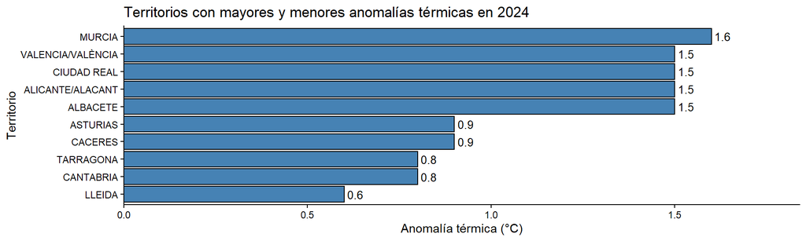

Los resultados muestran que todos los territorios analizados registraron temperaturas medias anuales superiores a las del periodo de 1991-2020. Las anomalías térmicas estuvieron entre +0,6 °C y +1,6 °C, con una media aproximada de +1,15 °C.

Murcia presentó la mayor anomalía térmica (+1,6 °C), mientras que Lleida registró la menor (+0,6 °C). Esto nos muestra que, aunque las temperaturas aumentaron en todas las provincias, las diferencias respecto al periodo de referencia no fueron iguales en todo el territorio.

## Unión de los datos climáticos y sanitarios

### Tabla resultante

Con las tablas ya preparadas y los nombres normalizados, se unen mediante `left_join()` utilizando la provincia como clave. El resultado es una tabla, `datos_completos`, con una fila por provincia que reúne la información de temperatura y los tres indicadores sanitarios.

Los partos prematuros se expresan como **tasa por cada 1.000 nacimientos**, dividiendo el número de partos prematuros entre los nacimientos de 2024 de cada provincia. De este modo se evita que las provincias más pobladas aparezcan con valores más altos solo porque tienen más nacimientos. La mortalidad fetal tardía y la perinatal ya vienen expresadas como tasas por mil nacidos.

| nombre | tmed_2024 | tmax_2024 | tmin_2024 | tmed_referencia | anomalia | provincia | partos_prematuros | mortalidad_fetal | mortalidad_perinatal | nacimientos_2024 | tasa_prematuros |
| --- | --- | --- | --- | --- | --- | --- | --- | --- | --- | --- | --- |
| A CORUÑA | 14.1 | 18.2 | 9.9 | 13.1 | 1 | A CORUNA | 311 | 2.41 | 3.1 | 5795 | 53.66695427092321 |
| ALBACETE | 16 | 22.5 | 9.6 | 14.5 | 1.5 | ALBACETE | 175 | 3.52 | 5.87 | 2545 | 68.762278978389 |
| ALICANTE/ALACANT | 18.2 | 23.6 | 12.7 | 16.7 | 1.5 | ALICANTE/ALACANT | 794 | 2.27 | 3.48 | 13207 | 60.11963352767471 |
| ALMERIA | 17.7 | 23 | 12.5 | 16.3 | 1.399999999999999 | ALMERIA | 386 | 2.43 | 5.16 | 6576 | 58.69829683698297 |
| ARABA/ALAVA | 12.7 | 18 | 7.4 | 11.7 | 1 | ARABA/ALAVA | 137 | 1.91 | 4.29 | 2094 | 65.42502387774594 |
| ASTURIAS | 12.8 | 17.3 | 8.3 | 11.9 | 0.9000000000000004 | ASTURIAS | 276 | 4.61 | 5.49 | 4535 | 60.85997794928335 |
| AVILA | 12.7 | 18.8 | 6.7 | 11.5 | 1.199999999999999 | AVILA | 32 | 0 | 1.17 | 854 | 37.47072599531616 |
| BADAJOZ | 17.6 | 24.1 | 11.1 | 16.7 | 0.9000000000000021 | BADAJOZ | 275 | 3.88 | 6.16 | 4364 | 63.01558203483043 |
| ILLES BALEARS | 18.1 | 23.2 | 13.1 | 17.1 | 1 | ILLES BALEARS | 520 | 3.63 | 6.04 | 9067 | 57.35083268997463 |
| BARCELONA | 15 | 20.7 | 9.2 | 14 | 1 | BARCELONA | 2233 | 3.14 | 4.44 | 39034 | 57.20653789004457 |

[output cut: 42 more lines]

El resultado es una única tabla denominada datos_completos, que reúne la información climática y sanitaria de las provincias españolas.

### Comprobación de la tabla final

Comprobamos que la tabla tiene una fila por provincia y se revisan los valores ausentes:

```r
nrow(datos_completos)
```

```
## [1] 52
```

```r
colSums(is.na(datos_completos))
```

```
##               nombre            tmed_2024            tmax_2024
##                    0                    0                    0
##            tmin_2024      tmed_referencia             anomalia
##                    0                    0                    0
##            provincia    partos_prematuros     mortalidad_fetal
##                    0                    0                    0
## mortalidad_perinatal     nacimientos_2024      tasa_prematuros
##                    0                    0                    0
```

Al comprobar los valores ausentes de la tabla final, se observa que ninguna variable presenta valores ausentes.

## Estudio de las posibles asociaciones entre temperatura y salud

Se estudian las asociaciones de los tres indicadores sanitarios (partos prematuros, mortalidad fetal tardía y mortalidad perinatal) con tres variables térmicas:

```
1. Temperatura media de 2024.
2. Temperatura máxima de 2024.
3. Anomalía térmica.
```

Para ello, utilizamos gráficos de dispersión y correlaciones estadísticas como Pearson y Spearman.

### Diagramas de dispersión

Representamos la relación entre las tres variables térmicas y cada indicador sanitario mediante diagramas de dispersión, en los que cada punto es una provincia.

```r
etiquetas_temp <- c(
  tmed_2024 = "Temperatura media 2024 (°C)",
  tmax_2024 = "Temperatura máxima 2024 (°C)",
  anomalia  = "Anomalía térmica (°C)"
)

grafico_dispersion <- function(indicador, etiqueta_y, titulo) {
  datos_completos %>%
    select(all_of(c(names(etiquetas_temp), indicador))) %>%
    pivot_longer(cols = all_of(names(etiquetas_temp)),
                 names_to = "variable", values_to = "temperatura") %>%
    mutate(variable = factor(variable,
                             levels = names(etiquetas_temp),
                             labels = unname(etiquetas_temp))) %>%
    ggplot(aes(x = temperatura, y = .data[[indicador]])) +
    geom_point(na.rm = TRUE) +
    geom_smooth(method = "lm", formula = y ~ x, se = FALSE, na.rm = TRUE) +
    facet_wrap(vars(variable), scales = "free_x") +
    labs(title = titulo, x = NULL, y = etiqueta_y) +
    theme_minimal()

}
```

#### Partos prematuros

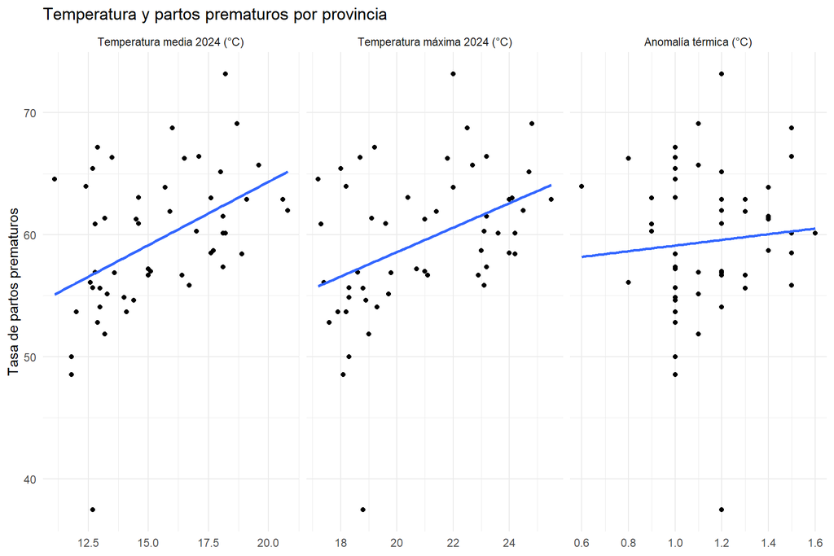

Con la temperatura media y la máxima, los puntos suben de izquierda a derecha: las provincias más cálidas tienden a tener algo más de partos prematuros por cada 1.000 nacimientos. Con la anomalía térmica, en cambio, la línea es casi plana, así que haber tenido un año más cálido de lo normal no parece relacionarse con la prematuridad. En todos los casos los puntos están bastante dispersos, por lo que la relación no es muy fuerte.

#### Mortalidad fetal tardía

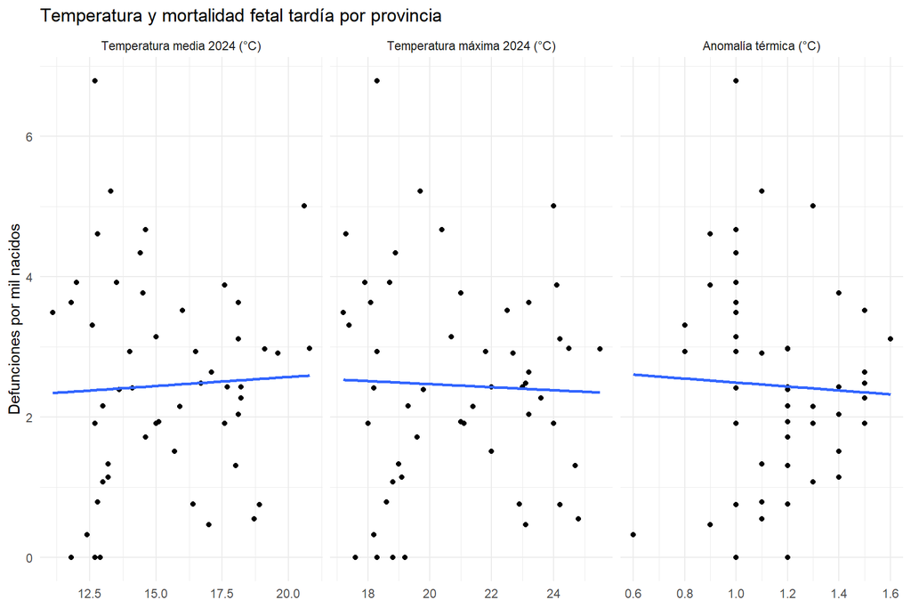

Los gráficos muestran una distribución dispersa de los datos y líneas de tendencia prácticamente horizontales. Se aprecia una ligera tendencia positiva con la temperatura media y negativa con la temperatura máxima y la anomalía térmica, pero no se observa una asociación visual clara.

#### Mortalidad perinatal

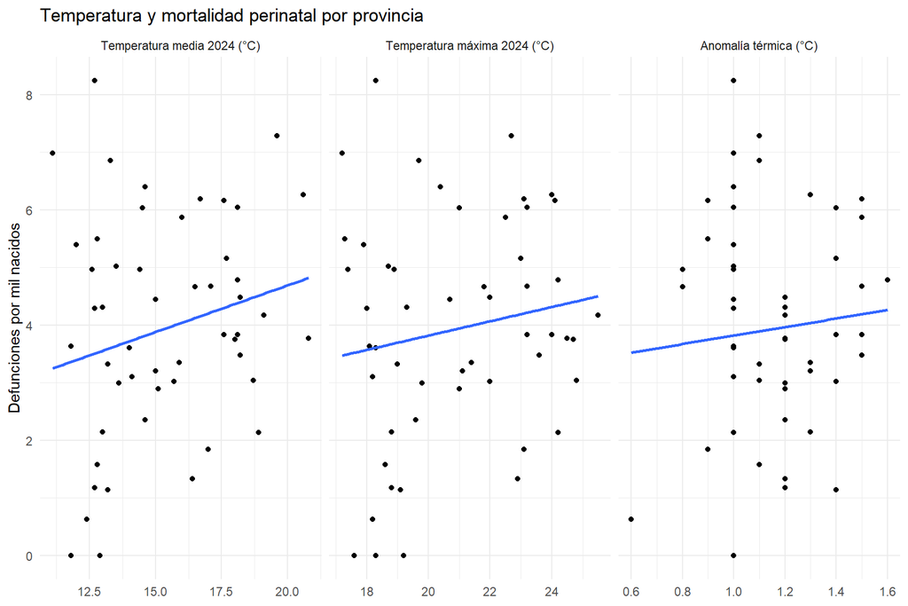

En los tres gráficos se observa una ligera tendencia positiva entre las variables climáticas y la mortalidad perinatal. Sin embargo, los puntos presentan bastante dispersión y la tendencia es poco marcada, por lo que no parece existir una relación clara entre estas variables. Para comprobarlo, será necesario analizar los resultados de las correlaciones.

### Correlaciones

Se utilizan dos métodos:

- **Pearson:** mide la relación lineal entre dos variables numéricas. Es sensible a valores extremos.
- **Spearman:** mide la relación monotónica (si una variable tiende a aumentar cuando aumenta la otra) a partir de los rangos, sin exigir linealidad.

Una correlación positiva indica que los valores altos de una variable tienden a acompañarse de valores altos de la otra, pero **no demuestra que una cause la otra**. Cada correlación se calcula con las provincias que tienen datos en ambas variables.

Correlaciones entre variables climáticas e indicadores sanitarios

| Indicador sanitario | Pearson Media | Pearson Máxima | Pearson Anomalía | Spearman Media | Spearman Máxima | Spearman Anomalía |
| --- | --- | --- | --- | --- | --- | --- |
| Partos prematuros | **0,443** p = 0,00102 | **0,411** p = 0,00248 | **0,082** p = 0,56181 | **0,443** p = 0,00101 | **0,415** p = 0,00224 | **0,107** p = 0,45134 |
| Mortalidad fetal | **0,044** p = 0,75658 | **-0,036** p = 0,79982 | **-0,040** p = 0,77846 | **0,059** p = 0,67660 | **-0,036** p = 0,80085 | **-0,093** p = 0,51296 |
| Mortalidad perinatal | **0,212** p = 0,13121 | **0,156** p = 0,26792 | **0,080** p = 0,57138 | **0,183** p = 0,19329 | **0,106** p = 0,45388 | **0,012** p = 0,93321 |

En conjunto, los resultados muestran que las asociaciones más destacadas se encuentran entre las temperaturas media y máxima anuales y la tasa de partos prematuros. Ambas presentan correlaciones positivas y estadísticamente significativas tanto con Pearson como con Spearman. Esto indica que las provincias con temperaturas más elevadas tienden a presentar mayores tasas de partos prematuros.

En cambio, la anomalía térmica no muestra una asociación significativa con este indicador. Tampoco se observan correlaciones estadísticamente significativas entre las variables climáticas y la mortalidad fetal o perinatal, cuyos coeficientes son generalmente próximos a cero.

Por tanto, los resultados sugieren una posible relación entre las temperaturas media y máxima anuales y la tasa de partos prematuros. Sin embargo, estos resultados muestran asociaciones estadísticas y no permiten establecer una relación de causalidad.

### Comparación por época del año: verano frente a invierno

La temperatura máxima anual mezcla los meses cálidos y los fríos. Para acercarnos más a la idea de calor, se calcula la media de las temperaturas máximas de **verano** (junio, julio y agosto) y de **invierno** (diciembre, enero y febrero), y se comparan sus correlaciones con los tres indicadores sanitarios. Si el calor fuera relevante, cabría esperar una asociación más clara en verano que en invierno; si fuera igual en ambas estaciones, probablemente reflejaría diferencias generales entre provincias.

Los indicadores sanitarios son anuales, así que no se puede asignar a cada embarazo la temperatura de los meses concretos en que ocurrió. Se compara si la asociación entre provincias cambia según la estación de la que se toma la temperatura.

Primero se calculan las dos variables y se añaden a la tabla `datos_completos`:

```
##   tmax_verano    tmax_invierno
##  Min.   :22.50   Min.   : 9.867
##  1st Qu.:27.73   1st Qu.:11.267
##  Median :29.50   Median :13.883
##  Mean   :29.52   Mean   :13.981
##  3rd Qu.:31.68   3rd Qu.:16.258
##  Max.   :35.30   Max.   :22.367
```

Los resultados muestran diferencias claras entre ambas estaciones. La temperatura máxima media es de 29,52 °C en verano, mientras que en invierno es de 13,98 °C. Esta diferencia también se observa en los valores mínimos, máximos y medianos, lo que confirma que las temperaturas son considerablemente más elevadas durante los meses de verano.

Después se calculan las correlaciones de Spearman. Cada fila es una época del año y cada columna un indicador sanitario:

```r
indicadores_salud <- c("tasa_prematuros", "mortalidad_fetal", "mortalidad_perinatal")

round(cor(datos_completos[, c("tmax_verano", "tmax_invierno")],
          datos_completos[, indicadores_salud],
          method = "spearman", use = "pairwise.complete.obs"), 2)
```

```
##               tasa_prematuros mortalidad_fetal mortalidad_perinatal
## tmax_verano              0.21            -0.18                -0.01
## tmax_invierno            0.45             0.09                 0.20
```

```r
round(cor(datos_completos[, c("tmax_verano", "tmax_invierno")],
          datos_completos[, indicadores_salud],
          method = "pearson", use = "pairwise.complete.obs"), 2)
```

```
##               tasa_prematuros mortalidad_fetal mortalidad_perinatal
## tmax_verano              0.18            -0.19                 0.01
## tmax_invierno            0.45             0.08                 0.20
```

Al comparar las correlaciones de ambas estaciones, se observa que la asociación más destacada corresponde a la tasa de partos prematuros, que presenta una correlación positiva tanto en verano como en invierno. Esta relación es más elevada durante el invierno, especialmente según Spearman (0,45), frente al valor obtenido en verano (0,21).

En cuanto a la mortalidad fetal, las correlaciones son débiles y cambian ligeramente de signo entre estaciones. Para la mortalidad perinatal, los coeficientes también son bajos, aunque se observa una correlación positiva algo mayor durante el invierno.

En general, las correlaciones obtenidas son más elevadas en invierno para los tres indicadores sanitarios, aunque esto no significa necesariamente que las asociaciones sean estadísticamente significativas.

El mapa de calor resume los coeficientes de Spearman:

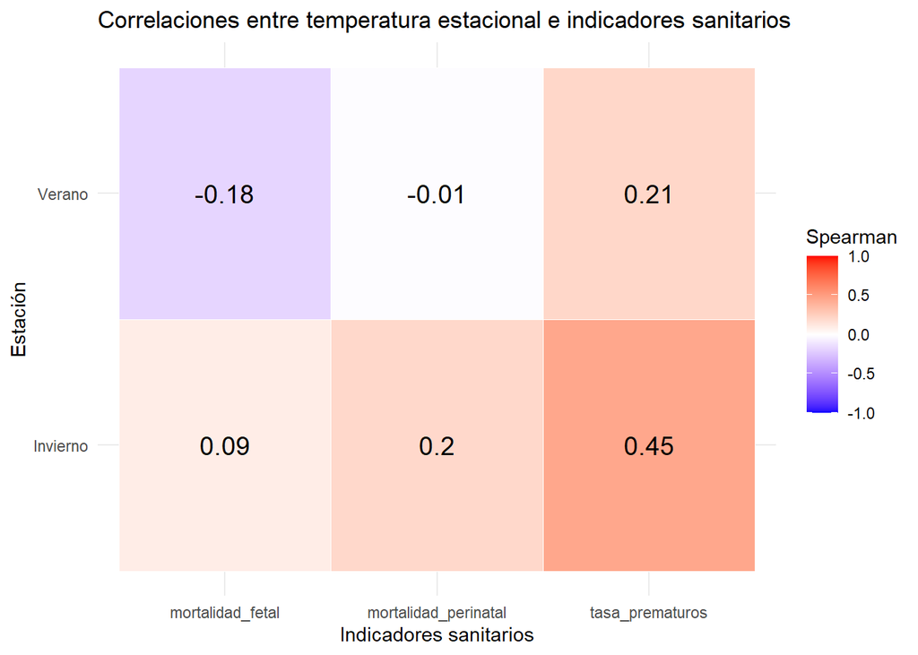

El mapa de calor permite visualizar de forma conjunta las correlaciones de Spearman entre las temperaturas máximas estacionales y los indicadores sanitarios. Se observa que la relación más destacada es la correspondiente a la tasa de partos prematuros durante el invierno. Por el contrario, las correlaciones con la mortalidad fetal y perinatal son más débiles y próximas a cero.

## Representación geográfica de los resultados

En este apartado representamos mediante mapas provinciales las anomalías térmicas y las tasas de mortalidad fetal tardía y perinatal registradas en el país en 2024. El objetivo es ver cómo se distribuyen estos indicadores y comprobar si existen patrones geográficos similares entre las temperaturas, la mortalidad y la tasa de partos prematuros.

### Preparación del mapa provincial

Usamos el paquete mapSpain para obtener el mapa de provincias españoles. Normalizamos sus nombres y los unimos con nuestra tabla de datos climáticos y sanitarios.

```
## character(0)
```

```
## [1] 0
```

### Mapa de anomalias térmicas

En este mapa representamos las anomalías térmicas de cada provincia durante 2024, tomando como referencia las temperaturas medias del periodo 1991-2020.

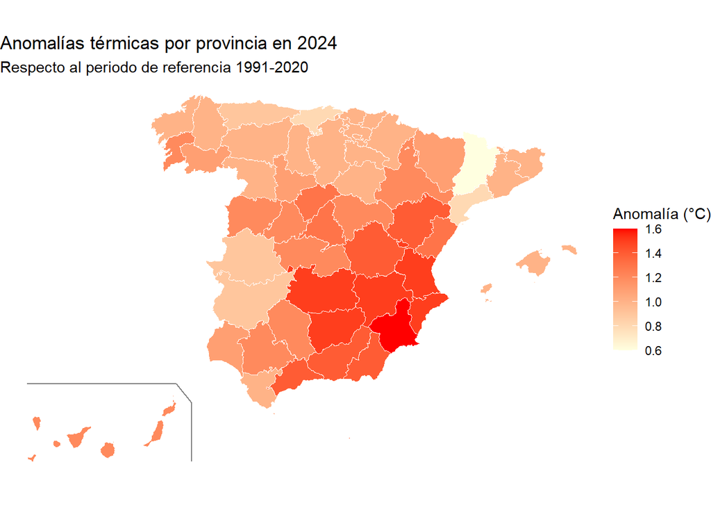

En el mapa vemos que todas las provincias registraron temperaturas superiores a lo habitual durante 2024, aunque el aumento no fue igual en todas. Las anomalías más altas se concentran sobre todo en el este y sureste de España, mientras que en el norte fueron, en general, más moderadas.

### Mapa de mortalidad fetal tardía

A continuación, se representa la tasa de mortalidad fetal tardía, la cual recoge los fallecimientos ocurridos antes del nacimiento en una etapa avanzada del embarazo. El mapa permite observar las diferencias entre provincias y compararlas con las anomalías térmicas.

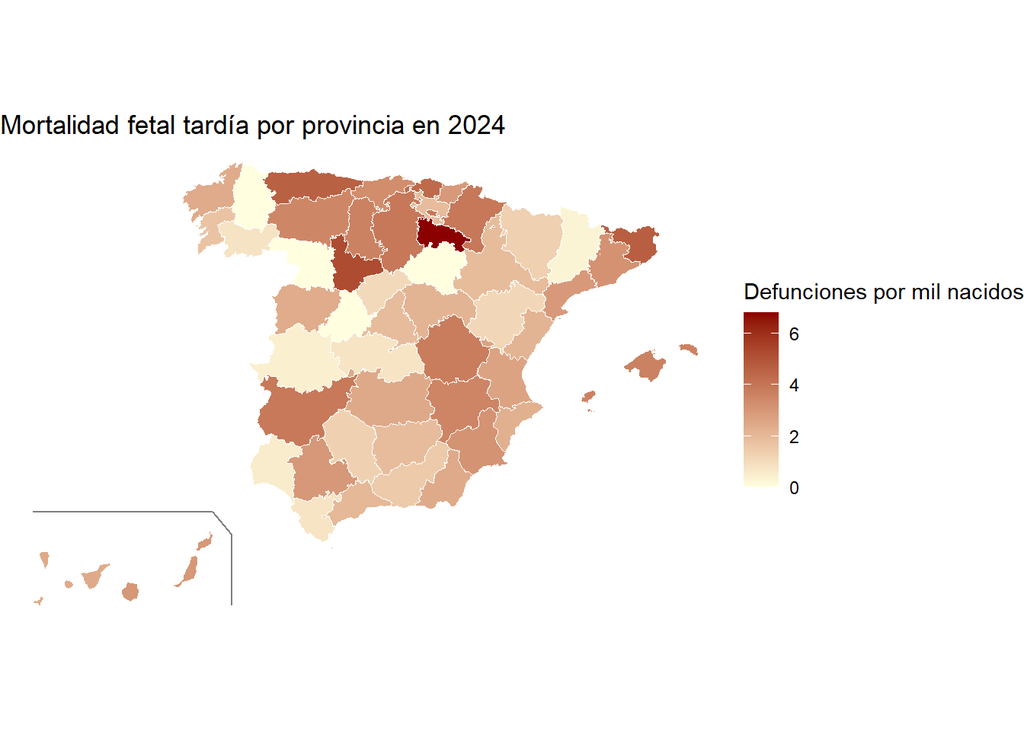

La tasa de mortalidad fetal tardía presenta diferencias entre provincias. Algunos de los valores más altos se encuentran en el norte de España, aunque no siguen un patrón geográfico claro. Si lo comparamos con las anomalías térmicas, vemos que las provincias con mayores aumentos de temperatura no son necesariamente las que presentan una mayor mortalidad fetal tardía.

### Mapa de mortalidad perinatal

Finalmente, representamos las tasa de mortalidad perinatal registrada en las provincias españolas en 2024. Así, podemos comparar su distribución con la mortalidad fetal tardía y las anomalías térmicas.

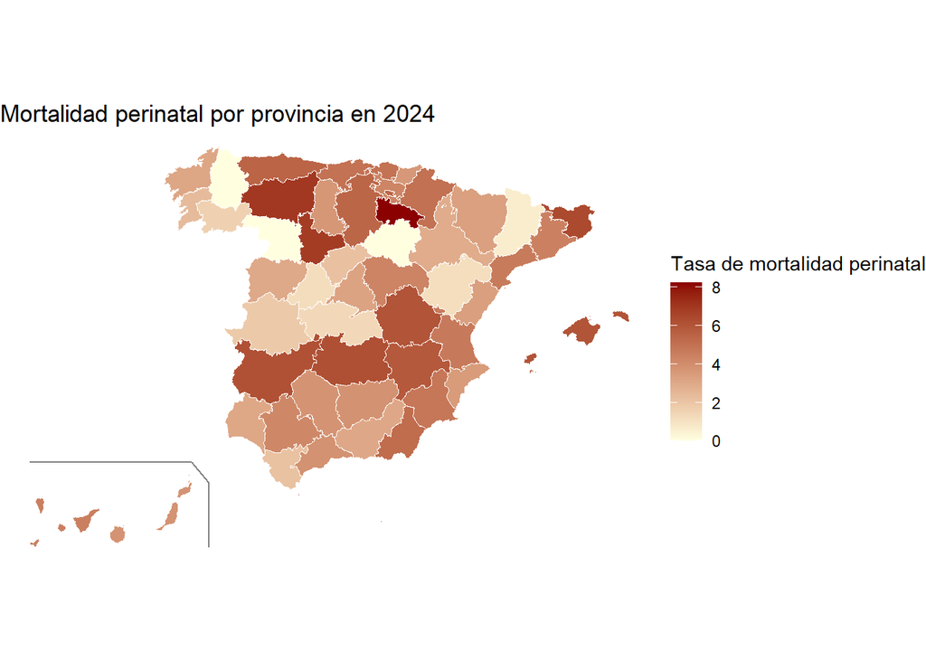

La mortalidad perinatal también varía entre provincias, con valores elevados en algunas zonas del norte y centro peninsular. Al compararla con las anomalías térmicas, tampoco se observa una coincidencia geográifca clara entre las provincias con mayores aumentos de temperatura y las que presentan tasas más altas de mortalidad perinatal.

### Mapa de partos prematuros

Por último, mostramos en el mapa la tasa de partos prematuros, es decir, el número de nacimientos por cada 1.000 de nacimientos que tienen lugar antes de la semana 37 de gestación. Así podemos ver qué provincias presentan valores más altos y comprobar si coinciden con las zonas donde se registraron mayores anomalías térmicas.

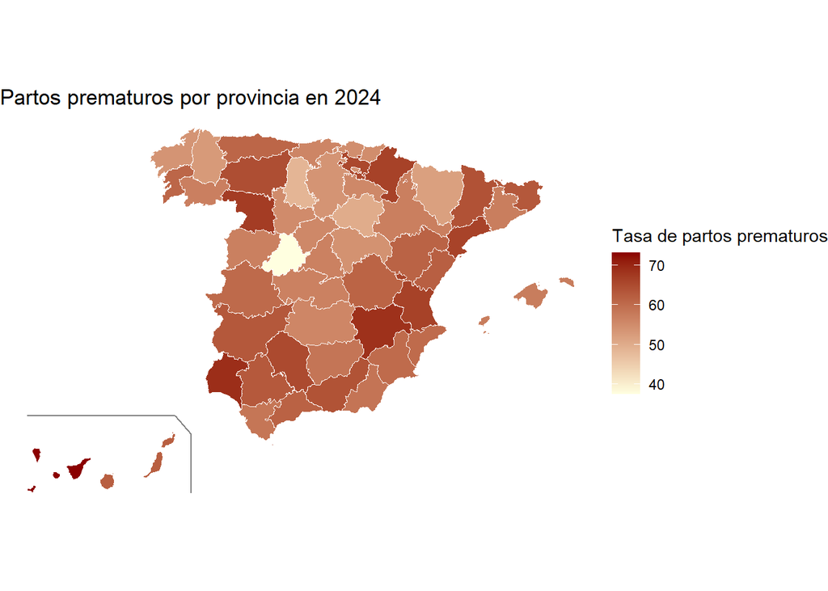

La prematuridad es más alta en Canarias, Huelva, Albacete y parte de la costa mediterránea, y más baja en el interior norte. Las mayores anomalías térmicas, en cambio, se concentran en el sureste, sobre todo en Murcia (1,6 °C). Algunas provincias coinciden en ambos mapas, como Albacete o Valencia, pero en general no se aprecia una relación clara entre ambas variables, posiblemente porque la prematuridad depende de muchos otros factores y los datos agregados por provincia y año pueden ocultar el efecto de episodios de calor concretos.

## Comparación entre grupos de provincias según el calor en verano

Para completar el análisis, se dividen las provincias en tres grupos del mismo tamaño según su temperatura máxima media de verano (junio, julio y agosto): **frías**, **templadas** y **calurosas**. Después se comparan los indicadores sanitarios entre los tres grupos. Este enfoque complementa el estudio de correlaciones: en lugar de tratar la temperatura como una variable continua, permite comparar directamente provincias con veranos muy distintos y comprobar si las conclusiones se mantienen con otro método. Si el calor influyera en las complicaciones del embarazo, cabría esperar valores más altos en el grupo de provincias calurosas.

### Creación de los grupos

```r
datos_grupos <- datos_completos %>%
  mutate(
    tercil = ntile(tmax_verano, 3),
    grupo_calor = case_when(
      tercil == 1 ~ "Frías",
      tercil == 2 ~ "Templadas",
      tercil == 3 ~ "Calurosas"
    ),
    grupo_calor = factor(grupo_calor, levels = c("Frías", "Templadas", "Calurosas"))
  )

# Número de provincias y rango de temperatura de cada grupo
datos_grupos %>%
  group_by(grupo_calor) %>%
  summarise(
    provincias = n(),
    tmax_verano_min = min(tmax_verano),
    tmax_verano_max = max(tmax_verano)
  )
```

```
## # A tibble: 3 × 4
##   grupo_calor provincias tmax_verano_min tmax_verano_max
##   <fct>            <int>           <dbl>           <dbl>
## 1 Frías               18            22.5            28.4
## 2 Templadas           17            28.5            31.2
## 3 Calurosas           17            31.5            35.3
```

```r
# Provincias que forman cada grupo
datos_grupos %>%
  select(provincia, tmax_verano, grupo_calor, tasa_prematuros) %>%
  arrange(grupo_calor, tmax_verano)
```

```
## # A tibble: 52 × 4
##    provincia              tmax_verano grupo_calor tasa_prematuros
##    <chr>                        <dbl> <fct>                 <dbl>
##  1 ASTURIAS                      22.5 Frías                  60.9
##  2 CANTABRIA                     22.8 Frías                  56.1
##  3 A CORUNA                      23.1 Frías                  53.7
##  4 GIPUZKOA                      23.7 Frías                  54.9
##  5 BIZKAIA                       24   Frías                  54.6
##  6 LUGO                          24.1 Frías                  52.8
##  7 SANTA CRUZ DE TENERIFE        25.3 Frías                  73.2
##  8 ARABA/ALAVA                   25.8 Frías                  65.4
##  9 PONTEVEDRA                    26.1 Frías                  60.9
## 10 LEON                          26.7 Frías                  64.5
## # ℹ 42 more rows
```

### Valores medios y medianos de cada grupo

```r
datos_grupos %>%
  group_by(grupo_calor) %>%
  summarise(across(
    c(tasa_prematuros, mortalidad_fetal, mortalidad_perinatal),
    list(
      media = ~ mean(.x, na.rm = TRUE),
      mediana = ~ median(.x, na.rm = TRUE)
    )
  ))
```

```
## # A tibble: 3 × 7
##   grupo_calor tasa_prematuros_media tasa_prematuros_mediana
##   <fct>                       <dbl>                   <dbl>
## 1 Frías                        59.4                    58.9
## 2 Templadas                    57.5                    57.4
## 3 Calurosas                    61.5                    61.3
## # ℹ 4 more variables: mortalidad_fetal_media <dbl>,
## #   mortalidad_fetal_mediana <dbl>, mortalidad_perinatal_media <dbl>,
## #   mortalidad_perinatal_mediana <dbl>
```

Ninguno de los tres indicadores aumenta de forma clara con el calor del verano. En los partos prematuros, las provincias calurosas tienen la tasa más alta (61,5 por cada 1.000 nacimientos), pero las frías (59,4) superan a las templadas (57,5), y las diferencias son pequeñas. Esto puede deberse a que la prematuridad depende más del clima de todo el año que del verano: Santa Cruz de Tenerife, por ejemplo, tiene un clima cálido pero veranos suaves, y queda en el grupo de las frías. En la mortalidad fetal tardía ocurre lo contrario de lo esperado, ya que la tasa baja de 2,91 por mil en las provincias frías a 2,09 en las calurosas, aunque al ser un suceso poco frecuente puede variar mucho por azar. En la mortalidad perinatal tampoco hay un patrón claro (4,21 en las frías, 3,63 en las templadas y 3,93 en las calurosas).

### Diagramas de caja por grupo

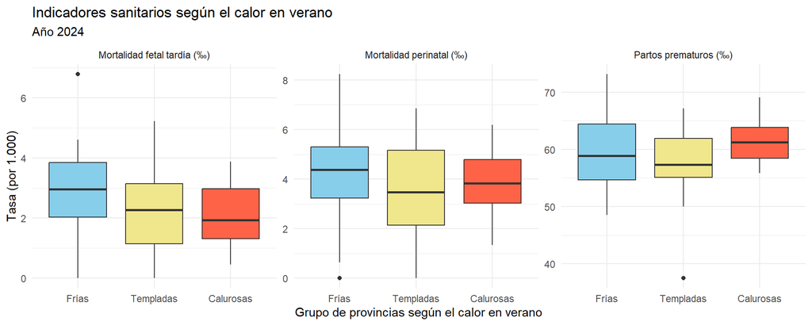

### ¿Las diferencias son significativas?

Para comprobar si las diferencias entre los tres grupos son reales o pueden deberse al azar, se utiliza la prueba de **Kruskal-Wallis**. Esta prueba compara tres o más grupos y no exige que los datos sigan una distribución normal, algo adecuado en este caso porque cada grupo tiene pocas provincias. Si el p-valor es menor que 0,05, al menos uno de los grupos es diferente de los demás.

```
##
##  Kruskal-Wallis rank sum test
##
## data:  tasa_prematuros by grupo_calor
## Kruskal-Wallis chi-squared = 3.2479, df = 2, p-value = 0.1971
```

```
##
##  Kruskal-Wallis rank sum test
##
## data:  mortalidad_fetal by grupo_calor
## Kruskal-Wallis chi-squared = 2.7167, df = 2, p-value = 0.2571
```

```
##
##  Kruskal-Wallis rank sum test
##
## data:  mortalidad_perinatal by grupo_calor
## Kruskal-Wallis chi-squared = 0.6898, df = 2, p-value = 0.7083
```

Ninguna de las tres pruebas resulta estadísticamente significativa. En la tasa de partos prematuros, el p-valor es de 0,197. En la mortalidad fetal tardía, de 0,257, y en la mortalidad perinatal, de 0,708. Al ser todos superiores a 0,05, no se encuentran diferencias significativas entre las provincias frías, templadas y calurosas en ninguno de los tres indicadores, por lo que no es necesario realizar comparaciones entre pares de grupos.

Esto no significa necesariamente que el calor no tenga ningún efecto. Con unas 17 provincias por grupo, la prueba tiene poca capacidad para detectar diferencias pequeñas. Además, los indicadores sanitarios son anuales, mientras que los grupos se han formado solo con la temperatura del verano: muchos de los partos del año no estuvieron expuestos a ese calor, lo que puede diluir cualquier efecto.

### Comparación según la temperatura media anual

Como se ha señalado, la prematuridad podría estar más relacionada con el clima general de la provincia que con el calor del verano. Para comprobarlo, se repite la agrupación usando la temperatura media anual.

```
## # A tibble: 3 × 4
##   grupo_anual provincias media_prematuros mediana_prematuros
##   <fct>            <int>            <dbl>              <dbl>
## 1 Frías               18             56.2               55.6
## 2 Templadas           17             59.7               57.2
## 3 Cálidas             17             62.7               62.0
```

```
##
##  Kruskal-Wallis rank sum test
##
## data:  tasa_prematuros by grupo_anual
## Kruskal-Wallis chi-squared = 9.9437, df = 2, p-value = 0.00693
```

Al agrupar las provincias según su temperatura media anual, el resultado cambia. La tasa media de partos prematuros aumenta de forma progresiva: 56,2 por cada 1.000 nacimientos en las provincias frías, 59,7 en las templadas y 62,7 en las cálidas. La prueba de Kruskal-Wallis indica que estas diferencias son significativas (p-valor = 0,007).

Esto confirma que la prematuridad se relaciona más con el clima general de la provincia a lo largo del año que con el calor del verano. Aun así, al tratarse de datos agregados por provincia, no puede afirmarse que la temperatura sea la causa, ya que las provincias cálidas pueden diferir también en otros factores, como la edad de las madres o la atención sanitaria.

Para identificar qué grupos se diferencian, se realizan comparaciones por pares mediante la prueba de Wilcoxon, con la corrección de Holm para tener en cuenta que se hacen varias comparaciones a la vez.

```
##
##  Pairwise comparisons using Wilcoxon rank sum exact test
##
## data:  datos_grupos_anual$tasa_prematuros and datos_grupos_anual$grupo_anual
##
##           Frías Templadas
## Templadas 0.11  -
## Cálidas   0.01  0.11
##
## P value adjustment method: holm
```

La única diferencia significativa se da entre las provincias cálidas y las frías (p-valor = 0,01). Las provincias templadas no se diferencian de forma significativa ni de las frías ni de las cálidas (p-valor = 0,11 en ambos casos), ya que ocupan una posición intermedia. Por tanto, el contraste se produce entre los dos extremos: las provincias con el clima más cálido a lo largo del año presentan una tasa de partos prematuros significativamente mayor que las provincias más frías.

## Conclusión

En este trabajo hemos estudiado la posible relación entre las temperaturas registradas durante 2024 y diferentes indicadores de salud materno-infantil en las provincias españolas. Hemos observado que todas las provincias tuvieron temperaturas superiores a las del periodo 1991-2020, aunque el aumento no fue igual en todas ellas. La anomalía media fue de +1,15 °C, un valor muy parecido al +1,1 °C registrado por la AEMET para la España peninsular (Agencia Estatal de Meteorología, 2025). Las mayores anomalías se concentraron principalmente en el este y sureste, destacando Murcia.

El resultado más destacado fue la relación entre las temperaturas medias y máximas anuales y la tasa de partos prematuros, ya que encontramos correlaciones positivas y estadísticamente significativas. Al comparar las provincias según su temperatura media anual, vimos que las más cálidas presentaban tasas de prematuridad superiores a las más frías. Este resultado va en la misma línea que otros estudios que han encontrado una relación entre las temperaturas elevadas y el riesgo de parto prematuro (Basu et al., 2010; Chersich et al., 2020; Vicedo-Cabrera et al., 2014). Sin embargo, al analizar las temperaturas del verano, esta relación no fue tan clara y las correlaciones fueron incluso mayores durante el invierno. Por tanto, es posible que nuestros resultados reflejen más las diferencias generales de clima entre provincias que el efecto de episodios concretos de calor.

En cuanto a la mortalidad fetal tardía y perinatal, no encontramos asociaciones estadísticamente significativas con las temperaturas. Esto podría deberse, en parte, a que son sucesos menos frecuentes y sus tasas pueden variar bastante entre provincias. Además, al comparar los mapas, tampoco observamos una coincidencia geográfica clara entre las provincias con mayores anomalías térmicas y las que presentaban tasas de mortalidad más elevadas.

Finalmente, se debe tener en cuenta que nuestro análisis se basa en datos provinciales de un solo año, así que no podemos confirmar que las temperaturas elevadas sean la causa de una mayor prematuridad. Tampoco conocemos las temperaturas a las que estuvo expuesta cada embarazada ni otros factores que podrían influir en los resultados. Sería interesante ampliar el estudio a varios años con datos más detallados sobre el embarazo y las condiciones de cada paciente. Con todo ello tenido en cuenta, se considera importante seguir investigando cómo puede afectar el calor a la salud materno-infantil y tener muy presentes a las embarazadas en las medidas de prevención frente a las temperaturas extremas.

## Bibliografía

- Agencia Estatal de Meteorología. (2025a). Avance climatológico nacional del año 2024. https://www.aemet.es/documentos/es/noticias/2025/01/resumen_clima_2024.pdf
- Basu, R., Malig, B. y Ostro, B. (2010). High ambient temperature and the risk of preterm delivery. American Journal of Epidemiology, 172(10), 1108–1117. https://doi.org/10.1093/aje/kwq170
- Chersich, M. F., Pham, M. D., Areal, A., Haghighi, M. M., Manyuchi, A., Swift, C. P., Wernecke, B., Robinson, M., Hetem, R., Boeckmann, M. y Hajat, S. (2020). Associations between high temperatures in pregnancy and risk of preterm birth, low birth weight, and stillbirths: Systematic review and meta-analysis. BMJ, 371, m3811. https://doi.org/10.1136/bmj.m3811
- Instituto Nacional de Estadística. (s. f.). INEbase. Recuperado el 23 de noviembre de 2026, de https://www.ine.es/
- Hernangómez, D. (2024). mapSpain: Administrative boundaries of Spain (Versión 0.9.0) [Paquete de R]. https://doi.org/10.5281/zenodo.5366622
- Kruskal, W. H. y Wallis, W. A. (1952). Use of ranks in one-criterion variance analysis. Journal of the American Statistical Association, 47(260), 583–621. https://doi.org/10.1080/01621459.1952.10483441
- Ooms, J. (2014). The jsonlite package: A practical and consistent mapping between JSON data and R objects [Preprint]. arXiv. https://doi.org/10.48550/arXiv.1403.2805
- Spearman, C. (1904). The proof and measurement of association between two things. The American Journal of Psychology, 15(1), 72–101. https://doi.org/10.2307/1412159
- Vicedo-Cabrera, A. M., Iñíguez, C., Barona, C. y Ballester, F. (2014). Exposure to elevated temperatures and risk of preterm birth in Valencia, Spain. Environmental Research, 134, 210–217. https://doi.org/10.1016/j.envres.2014.07.021
- Pearson, K. (1895). Notes on regression and inheritance in the case of two parents. Proceedings of the Royal Society of London, 58, 240–242. https://doi.org/10.1098/rspl.1895.0041
- DT: An R interface to the DataTables library. (s. f.). https://rstudio.github.io/DT/